# DVF Script 3

[Boris Mericskay](https://perso.univ-rennes2.fr/boris.mericskay) et [Florent Demoraes](https://perso.univ-rennes2.fr/florent.demoraes)

02/07/2021 - Mise à jour 08/10/2026

# 1 LES DONNÉES DVF EN CARTES POUR SAISIR LES GRANDES TENDANCES SPATIALES DE L’IMMOBILIER

Ce script décrit plusieurs fonctions de manipulation de la dimension spatiale des données DVF. Il propose aussi plusieurs formes de représentation cartographique de ces données à une échelle régionale (Bretagne).

## 1.1 Chargement des packages nécessaires

```r
library(tidyverse) # Manipulation de données
library(sf) # Manipulation de données spatiales
library(mapsf) # Cartographie thématique
library(spdep) # pour calculer l'auto-corrélation spatiale
library(spatstat) # pour produire des surfaces lissées
library(terra) # pour le traitement de données raster
library(cartogramR) # pour créer des cartogrammes contigus
library(rmapshaper) # pour généraliser les contours
library(cluster) # CAH
library(data.table) # pour manipuler des tables volumineuses et réaliser des agrégations avec une performance accrue
library(tanaka) # pour élaborer des cartes selon la méthode des contours de relief
library(linemap) # pour élaborer des cartes en stalagmites avec un figuré en lignes de crête
library(sfarrow) # pour lire et écrire des fichiers geoparquets
```

## 1.2 Import du jeu de données brut

```r
# import du fichier csv avec la fonction fastread du package data.table
DVFOK <- fread("Resultats/DVFOK.csv")
```

## 1.3 Création d’un semis de points correspondant aux mutations et reprojection

### 1.3.1 Transformer le tableau des mutations en couche spatiale (objet sf) à partir des coordonnées XY

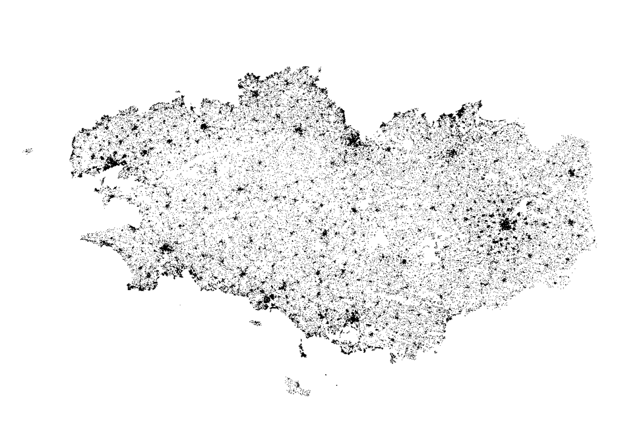

```r
DVFgeo <- st_as_sf(DVFOK, coords = c("longitude","latitude"), crs = 4326)
# Paramétrage des marges de la fenêtre pour maximiser l'emprise de la carte
op <- par(mar = c(0, 0, 1.2, 0))
plot(st_geometry(DVFgeo), pch = ".", cex = 0.01)
```

```r
par(op) # pour réinitialiser les paramètres de la fenêtre graphique
```

### 1.3.2 Reprojeter la couche des mutations DVF en Lambert 93

```r
DVFgeo <- st_transform(DVFgeo, 2154)
```

### 1.3.3 Exporter le semis de points des mutations au format geoparquet (écriture très rapide)

```r
# pour créer un dossier (s'il n'existe pas déjà)
dir.create("Resultats")
st_write_parquet(DVFgeo, "Resultats/Mutations_Bzh.parquet")
```

## 1.4 Ajout de couches géographiques externes pour les analyses/cartes

### 1.4.1 Importer la couche des départements et la reprojeter en Lambert 93

```r
departements <- st_read("Donnees/DEPARTEMENT.shp") # Source : Admin Express IGN (France entière)
departements <- st_transform(departements, 2154)
```

### 1.4.2 Importer la couche des communes de Bretagne

```r
Communes <- st_read("Donnees/Communes.shp") # source : Admin Express IGN (Bretagne)
```

### 1.4.3 Fusion des communes pour récuperer les contours des départements bretons

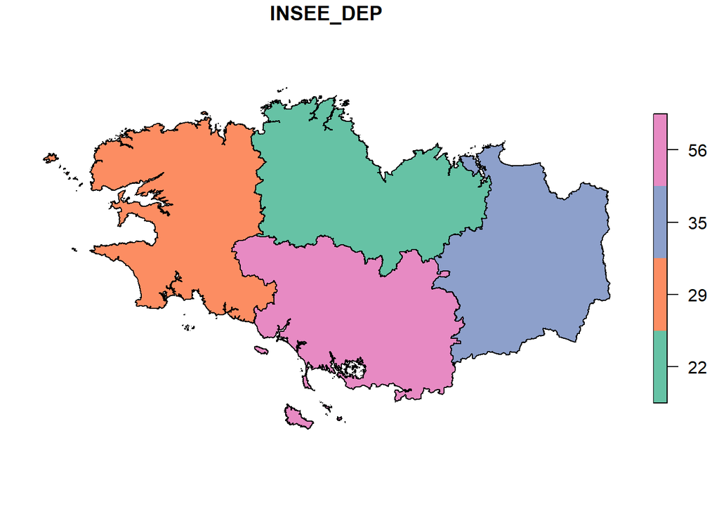

```r
depBZH <- Communes %>% group_by(INSEE_DEP) %>% summarize()
plot(depBZH["INSEE_DEP"])
```

## 1.5 Agrégations spatiales

### 1.5.1 Dénombrement des mutations par commune (jointure spatiale et comptage)

```r
Communes <- Communes %>% mutate(NbMutations = lengths(st_intersects(Communes, DVFgeo)))
sum(Communes$NbMutations) # nb total de mutations
```

```
## [1] 247646
```

### 1.5.2 Carte du nombre de mutations par commune

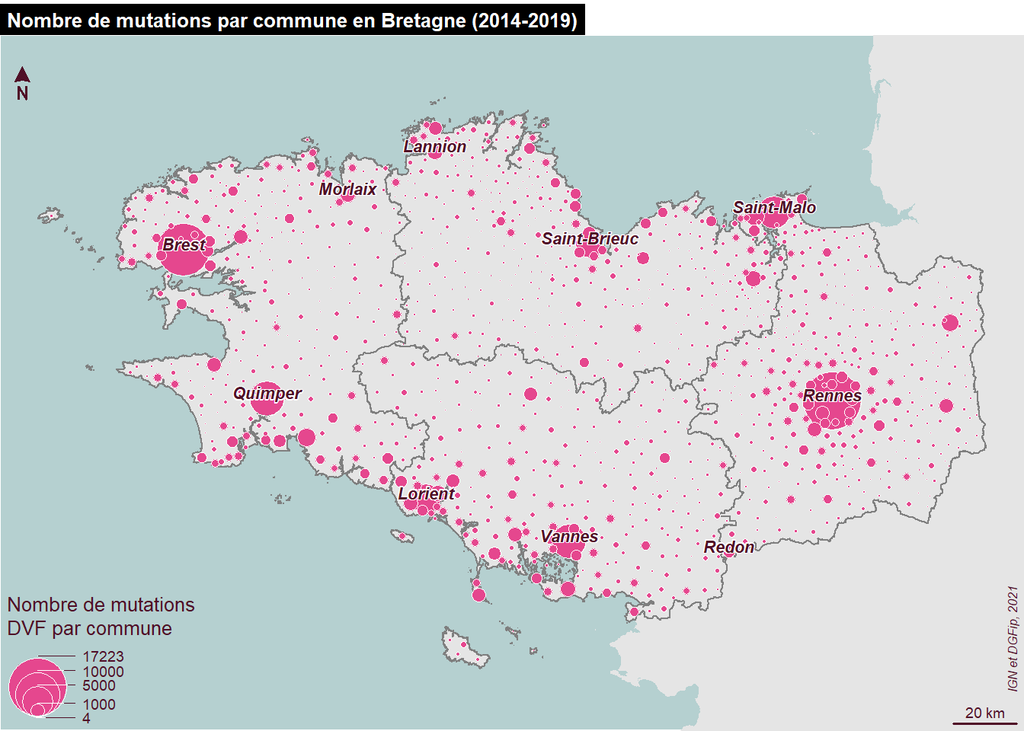

```r
# Paramétrage des marges de la fenêtre pour maximiser l'emprise de la carte
op <- par(mar = c(0, 0, 1.2, 0))

# sélection des communes dont le nom sera affiché sur la carte
liste_noms <- c("Rennes", "Redon", "Vannes", "Lorient", "Quimper", "Brest", "Morlaix", "Lannion", "Saint-Brieuc", "Saint-Malo")
Selection_Communes <- Communes[Communes$NOM_COM %in% liste_noms, ]

# Affichage de tous les départements en arrière-plan, en centrant la carte sur la région Bretagne
plot(st_geometry(departements), col = "grey90", border = NA, bg = "#B5D0D0", xlim = c(st_bbox(Communes)[1], st_bbox(Communes)[3]), ylim = c(st_bbox(Communes)[2], st_bbox(Communes)[4]))

# Ajout des departements de la région
plot(st_geometry(depBZH), lwd = 1, col = NA, border = "grey50", add = TRUE)

# Affichage des symboles proportionnels (nombre de mutations)
mf_map(x = Communes,
       type = "prop",
          var = "NbMutations", # variable à cartographier
          col = "#e5478e", # couleur des cercles
          border = "white",  # couleur du contour des cercles
          inches = 0.2, # taille du cercle max
          lwd = 0.01, # épaisseur du contour des cercles
          leg_title = "Nombre de mutations \nDVF par commune", leg_pos = "bottomleft")

# Ajouter les étiquettes des communes sélectionnées plus haut
mf_label(Selection_Communes, var = "NOM_COM", halo = TRUE, bg = "white", r = 0.05, cex = 0.7, pos = 3, font = 4, offset = 0)

# Habillage de la carte
mf_title("Nombre de mutations par commune en Bretagne (2014-2019)", cex = 0.8, tab = TRUE, fg = "white", bg = "black", line = 1, pos = "left")

mf_arrow(adj = c(1,-3))
mf_scale()

mf_credits(txt = "          IGN et DGFip, 2021", cex = 0.5, pos = 'rightbottom')
```

```r
par(op) # pour réinitialiser les paramètres de la fenêtre graphique
```

### 1.5.3 Dénombrement du nombre de mutations de maisons et d’appartements par commune

```r
Maisons <- DVFgeo %>%
  filter(type == 'Maison')

Appartements <- DVFgeo %>%
  filter(type == "Appartement")

Communes <- Communes %>%
  mutate(NbMaisons = lengths(st_intersects(Communes, Maisons))) %>%
  mutate(NbAppart = lengths(st_intersects(Communes, Appartements)))
```

### 1.5.4 Carte du nombre de ventes de maisons par commune

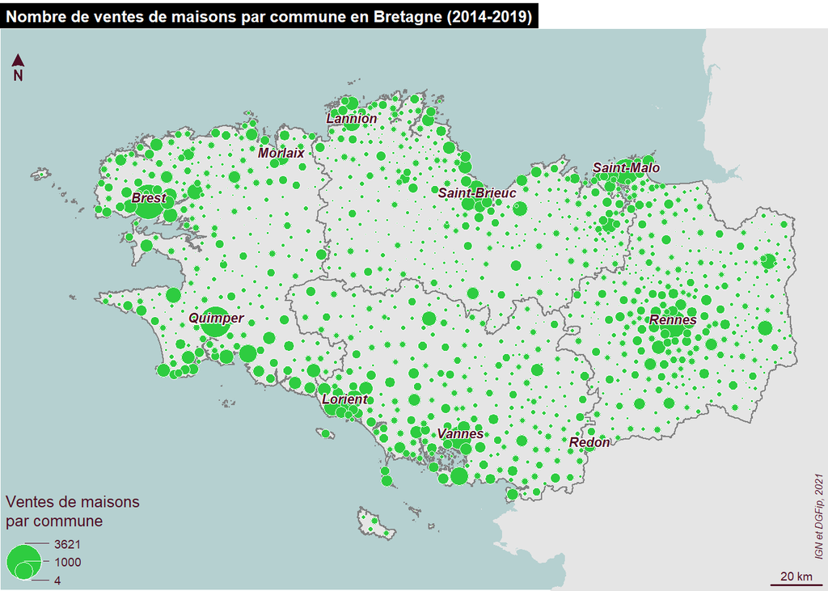

```r
# Paramétrage des marges de la fenêtre pour maximiser l'emprise de la carte
op <- par(mar = c(0, 0, 1.2, 0))

# Affichage de tous les départements en arrière-plan, en centrant la carte sur la région Bretagne
plot(st_geometry(departements), col = "grey90", border = NA, bg = "#B5D0D0", xlim = c(st_bbox(Communes)[1], st_bbox(Communes)[3]), ylim = c(st_bbox(Communes)[2], st_bbox(Communes)[4]))

# Ajout des departements de la région
plot(st_geometry(depBZH), lwd = 1, col = NA, border = "grey50", add = TRUE)

# Affichage des symboles proportionnels (nombre de mutations de maisons)
mf_map(x = Communes,
       type = "prop",
          var = "NbMaisons", # variable à cartographier
          col = "#2ECC40", # couleur des cercles
          border = "white",  # couleur du contour des cercles
          inches = 0.15, # taille du cercle max
          lwd = 0.01, # épaisseur du contour des cercles
          leg_title = "Ventes de maisons \npar commune", leg_pos = "bottomleft")

# Ajouter les étiquettes des communes sélectionnées plus haut
mf_label(Selection_Communes, var = "NOM_COM", halo = TRUE, bg = "white", r = 0.05, cex = 0.7, pos = 3, font = 4, offset = 0)

# Habillage de la carte
mf_title("Nombre de ventes de maisons par commune en Bretagne (2014-2019)", cex = 0.8, tab = TRUE, fg = "white", bg = "black", line = 1, pos = "left")

mf_arrow(adj = c(1,-3))
mf_scale()

mf_credits(txt = "          IGN et DGFip, 2021", cex = 0.5, pos = 'rightbottom')
```

```r
par(op) # pour réinitialiser les paramètres de la fenêtre graphique
```

### 1.5.5 Carte du nombre de ventes d’appartements par commune

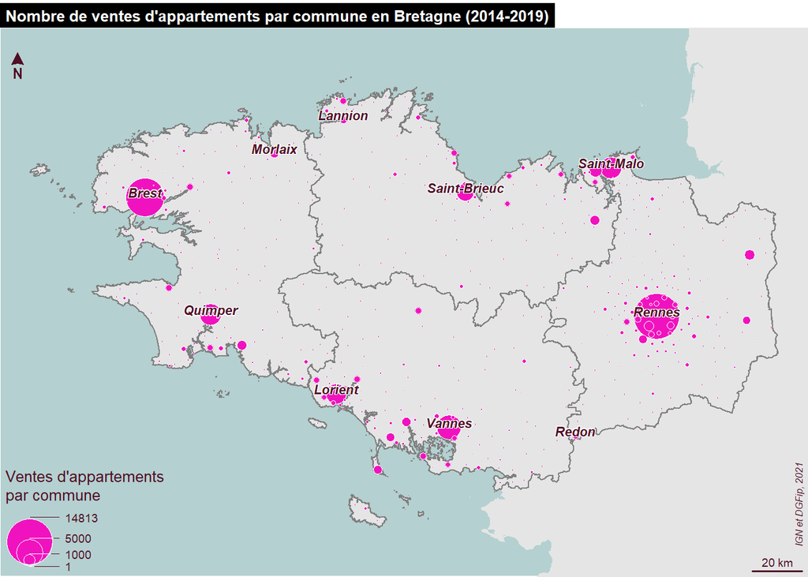

```r
# Paramétrage des marges de la fenêtre pour maximiser l'emprise de la carte
op <- par(mar = c(0, 0, 1.2, 0))

# Affichage de tous les départements en arrière-plan, en centrant la carte sur la région Bretagne
plot(st_geometry(departements), col = "grey90", border = NA, bg = "#B5D0D0", xlim = c(st_bbox(Communes)[1], st_bbox(Communes)[3]), ylim = c(st_bbox(Communes)[2], st_bbox(Communes)[4]))

# Ajout des departements de la région
plot(st_geometry(depBZH), lwd = 1, col = NA, border = "grey50", add = TRUE)

# Affichage des symboles proportionnels (nombre de mutations d'appartements)
mf_map(x = Communes,
       type = "prop",
          var = "NbAppart", # variable à cartographier
          col = "#F012BE", # couleur des cercles
          border = "white",  # couleur du contour des cercles
          inches = 0.2, # taille du cercle max
          lwd = 0.01, # épaisseur du contour des cercles
          leg_title = "Ventes d'appartements \npar commune",
       leg_pos = "bottomleft")

# Ajouter les étiquettes des communes sélectionnées plus haut
mf_label(Selection_Communes, var = "NOM_COM", halo = TRUE, bg = "white", r = 0.05, cex = 0.7, pos = 3, font = 4, offset = 0)

# Habillage de la carte
mf_title("Nombre de ventes d'appartements par commune en Bretagne (2014-2019)", cex = 0.8, tab = TRUE, fg = "white", bg = "black", line = 1, pos = "left")

mf_arrow(adj = c(1,-3))
mf_scale()

mf_credits(txt = "          IGN et DGFip, 2021", cex = 0.5, pos = 'rightbottom')
```

```r
par(op) # pour réinitialiser les paramètres de la fenêtre graphique
```

### 1.5.6 Calcul du prix nominal moyen, du prix moyen au m² et de la surface moyenne par commune

```r
# pour récupérer l'id des communes sur chaque mutation
DVFgeo.tmp <- st_join(DVFgeo, Communes["INSEE_COM"]) |>
  st_drop_geometry()

# pour calculer le prix nominal moyen, le prix moyen au m2 et la surface moyenne des mutations par commune (on utilise ici le package data.table pour optimiser le temps de calcul)
setDT(DVFgeo.tmp)  # Convertir le dataframe en data.table

communes.enrichies <- DVFgeo.tmp[, .(
  Nb_Mutations   = .N,
  PrixMoyen      = round(mean(prix, na.rm = TRUE)),
  Prixm2Moyen    = round(mean(prixm2, na.rm = TRUE)),
  SurfaceMoyenne = round(mean(surface, na.rm = TRUE))
), by = INSEE_COM]

# pour récupérer les nouvelles variables dans la couche des communes initiales
Communes <- merge(Communes, communes.enrichies, by = "INSEE_COM")
rm(communes.enrichies, DVFgeo.tmp)
```

### 1.5.7 Carte du prix moyen au m² des mutations par commune

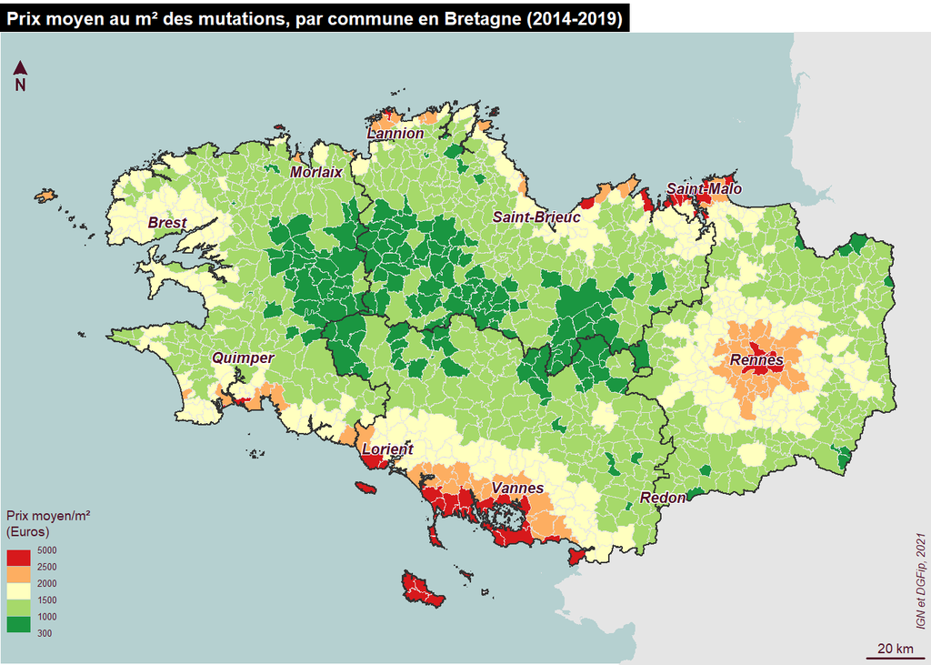

```r
# Paramétrage des marges de la fenêtre pour maximiser l'emprise de la carte
op <- par(mar = c(0, 0, 1.2, 0))

# Affichage de tous les départements en arrière-plan, en centrant la carte sur la région Bretagne
plot(st_geometry(departements), col = "grey90", border = NA, bg = "#B5D0D0", xlim = c(st_bbox(Communes)[1], st_bbox(Communes)[3]), ylim = c(st_bbox(Communes)[2], st_bbox(Communes)[4]))

mf_map(
  x = Communes,
  var = "Prixm2Moyen",
  type = "choro",
  breaks = c(300, 1000, 1500, 2000, 2500, 5000),
  pal = c("#1a9641", "#a6d96a", "#ffffbf", "#fdae61", "#d7191c"),
  lwd = 0.001,
  border = "grey90",
  leg_title = "Prix moyen/m² \n(Euros)",
  leg_pos = "bottomleft",
  leg_box_border = "#B5D0D0",
  leg_no_data = "",
  col_na = NA,
  leg_val_rnd = 0,
  leg_title_cex = 0.6,
  leg_val_cex = 0.4,
  leg_size = 0.7,
  add = TRUE
)

# Ajout des départements de la région
plot(st_geometry(depBZH), lwd = 1, col = NA, border = "grey20", add = TRUE)

# Ajouter les étiquettes des communes sélectionnées plus haut
mf_label(Selection_Communes, var = "NOM_COM", halo = TRUE, bg = "white", r = 0.05, cex = 0.7, pos = 3, font = 4, offset = 0)

# Habillage de la carte
mf_title("Prix moyen au m² des mutations, par commune en Bretagne (2014-2019)", cex = 0.8, tab = TRUE, fg = "white", bg = "black", line = 1, pos = "left")

mf_arrow(adj = c(1,-3))
mf_scale()

mf_credits(txt = "          IGN et DGFip, 2021", cex = 0.5, pos = 'rightbottom')
```

```r
par(op) # pour réinitialiser les paramètres de la fenêtre graphique
```

### 1.5.8 Carte du prix nominal moyen des mutations par commune

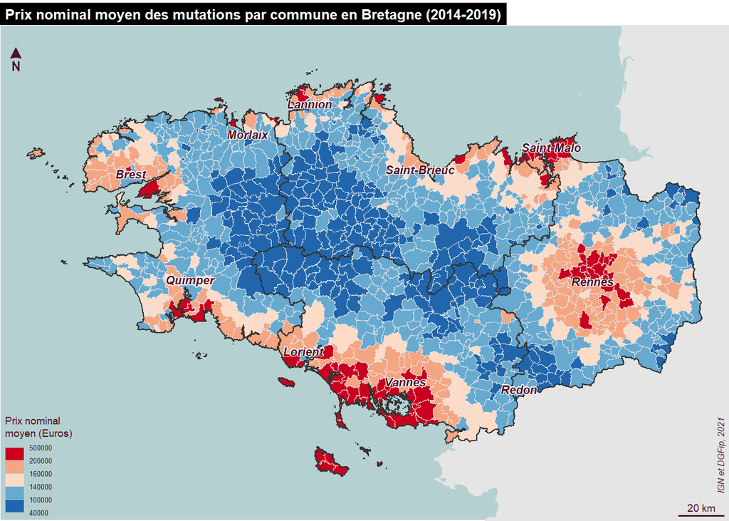

```r
# Paramétrage des marges de la fenêtre pour maximiser l'emprise de la carte
op <- par(mar = c(0, 0, 1.2, 0))

# Affichage de tous les départements en arrière-plan, en centrant la carte sur la région Bretagne
plot(st_geometry(departements), col = "grey90", border = NA, bg = "#B5D0D0", xlim = c(st_bbox(Communes)[1], st_bbox(Communes)[3]), ylim = c(st_bbox(Communes)[2], st_bbox(Communes)[4]))

options("scipen" = 100)  # permet de convertir les chiffres initialement sous forme d'exposants en chiffres décimaux standard (utile pour l'affichage des valeurs en légende)

mf_map(
  x = Communes,
  var = "PrixMoyen",
  type = "choro",
  breaks = c(40000, 100000, 140000, 160000, 200000, 500000),
  pal = c("#2166ac","#67a9cf", "#fddbc7","#f4a582","#ca0020"),
  lwd = 0.001,
  border = "grey90",
  leg_title = "Prix nominal \nmoyen (Euros)",
  leg_pos = "bottomleft",
  leg_box_border = "#B5D0D0",
  leg_no_data = "",
  col_na = NA,
  leg_val_rnd = 0,
  leg_title_cex = 0.6,
  leg_val_cex = 0.4,
  leg_size = 0.7,
  add = TRUE
)

# Ajout des départements de la région
plot(st_geometry(depBZH), lwd = 1, col = NA, border = "grey20", add = TRUE)

# Ajouter les étiquettes des communes sélectionnées plus haut
mf_label(Selection_Communes, var = "NOM_COM", halo = TRUE, bg = "white", r = 0.05, cex = 0.7, pos = 3, font = 4, offset = 0)

# Habillage de la carte
mf_title("Prix nominal moyen des mutations par commune en Bretagne (2014-2019)", cex = 0.8, tab = TRUE, fg = "white", bg = "black", line = 1, pos = "left")

mf_arrow(adj = c(1,-3))
mf_scale()

mf_credits(txt = "          IGN et DGFip, 2021", cex = 0.5, pos = 'rightbottom')
```

### 1.5.9 Export des communes enrichies et des départements bretons au format geopackage (pour une utilisation dans un SIG par exemple)

```r
st_write(Communes, "Resultats/CommunesBZHDVF.gpkg", append = FALSE)
```

```
## Deleting layer `CommunesBZHDVF' using driver `GPKG'
## Writing layer `CommunesBZHDVF' to data source
##   `Resultats/CommunesBZHDVF.gpkg' using driver `GPKG'
## Writing 1206 features with 19 fields and geometry type Multi Polygon.
```

```r
st_write(depBZH, "Resultats/DepartementsBZH.gpkg", append = FALSE)
```

```
## Deleting layer `DepartementsBZH' using driver `GPKG'
## Writing layer `DepartementsBZH' to data source
##   `Resultats/DepartementsBZH.gpkg' using driver `GPKG'
## Writing 4 features with 1 fields and geometry type Multi Polygon.
```

### 1.5.10 Partitionnement régulier de l’espace et calcul du prix moyen au m² dans ce découpage

#### 1.5.10.1 Création d’un carroyage avec des mailles de 2 km de côté

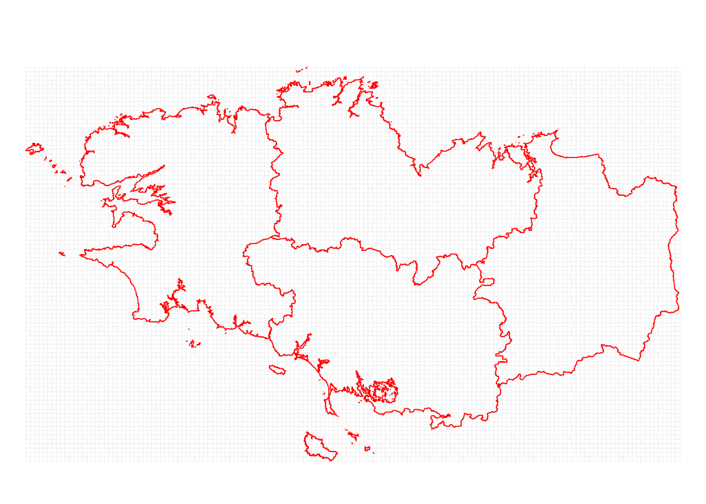

```r
# Paramétrage des marges de la fenêtre pour maximiser l'emprise de la carte
op <- par(mar = c(0, 0, 1.5, 0))

grille <- st_make_grid(
  Communes,
  cellsize = 2000,
  crs = 2154,
  what = "polygons",
  square = TRUE)

# Création d'un identifiant unique par maille
grille <- st_as_sf(grille)
grille <- grille %>% mutate(IDOK = row_number())

# Paramétrage des marges de la fenêtre pour maximiser l'emprise de la carte
par(mar = c(0, 0, 1.2, 0))

plot(st_geometry(grille), border = "grey90", lwd = 0.01, lty = 3)
plot(st_geometry(depBZH), lwd = 1, border = "red", add = TRUE)
```

```r
par(op) # pour réinitialiser les paramètres de la fenêtre graphique
```

#### 1.5.10.2 Calcul du nombre de mutations et du prix moyen au m² par maille

```r
# pour récupérer l'id des mailles sur chaque mutation (jointure spatiale)
DVFgeobis <- st_join(DVFgeo, grille["IDOK"]) |>
  st_drop_geometry()

# pour calculer le nombre de mutations et leur prix moyen par maille (on utilise ici à nouveau le package data.table pour optimiser le temps de calcul)
setDT(DVFgeobis)  # Convertir le dataframe en data.table
grille.enrichie <- DVFgeobis[, .(Nb_Mutations = .N,
                                 prixm2moyen = round(mean(prixm2))),
                             by = IDOK]

# jointure attributaire pour récupérer les résultats dans la grille sf
grillem2 <- merge(grille, grille.enrichie, by = "IDOK", all = TRUE)
rm(DVFgeobis, grille.enrichie)
```

#### 1.5.10.3 Carte du prix au m² moyen de l’immobilier par maille de 2km

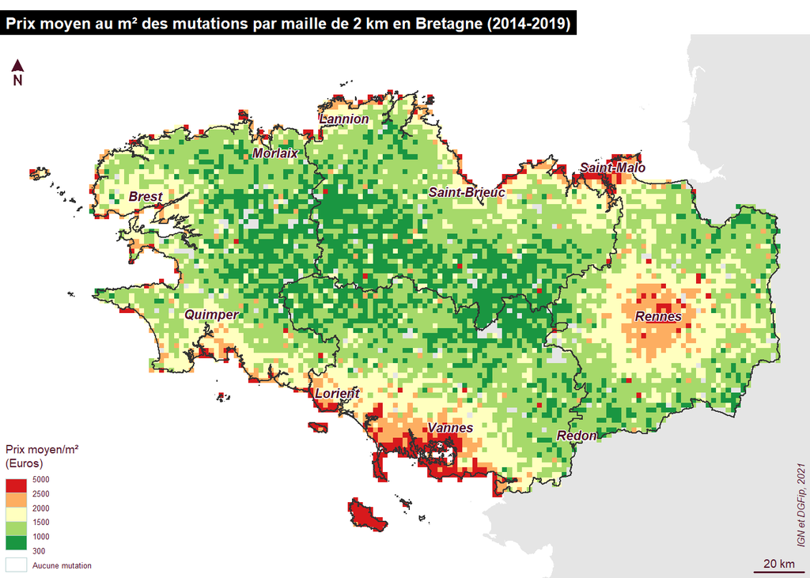

```r
# Paramétrage des marges de la fenêtre pour maximiser l'emprise de la carte
op <- par(mar = c(0, 0, 1.5, 0))

# Affichage de tous les départements en arrière-plan, en centrant la carte sur la région Bretagne
plot(st_geometry(departements), col = "grey90", border = NA, bg = NA, xlim = c(st_bbox(Communes)[1], st_bbox(Communes)[3]), ylim = c(st_bbox(Communes)[2], st_bbox(Communes)[4]))

mf_map(
  x = grillem2,
  var = "prixm2moyen",
  type = "choro",
  breaks = c(300, 1000, 1500, 2000, 2500, 5000),
  pal = c("#1a9641", "#a6d96a", "#ffffbf", "#fdae61", "#d7191c"),
  lwd = 0.001,
  border = NA,
  leg_title = "Prix moyen/m² \n(Euros)",
  leg_pos = "bottomleft",
  leg_box_border = "#B5D0D0",
  leg_no_data = "Aucune mutation",
  col_na = NA,
  leg_val_rnd = 0,
  leg_title_cex = 0.6,
  leg_val_cex = 0.4,
  leg_size = 0.7,
  add = TRUE
)

# Ajout des départements de la région
plot(st_geometry(depBZH), lwd = 1, col = NA, border = "grey20", add = TRUE)

# Ajouter les étiquettes des communes sélectionnées plus haut
mf_label(Selection_Communes, var = "NOM_COM", halo = TRUE, bg = "white", r = 0.05, cex = 0.7, pos = 3, font = 4, offset = 0)

# Habillage de la carte
mf_title("Prix moyen au m² des mutations par maille de 2 km en Bretagne (2014-2019)", cex = 0.8, tab = TRUE, fg = "white", bg = "black", line = 1, pos = "left")

mf_arrow(adj = c(1,-3))
mf_scale()

mf_credits(txt = "          IGN et DGFip, 2021", cex = 0.5, pos = 'rightbottom')
```

```r
par(op) # pour réinitialiser les paramètres de la fenêtre graphique
```

### 1.5.11 Export du carroyage au format geopackage

```r
st_write(grillem2, "Resultats/grillem2.gpkg", append = FALSE) # pour une utilisation dans un SIG par exemple
```

```
## Deleting layer `grillem2' using driver `GPKG'
## Writing layer `grillem2' to data source `Resultats/grillem2.gpkg' using driver `GPKG'
## Writing 13741 features with 3 fields and geometry type Polygon.
```

## 1.6 Lissage spatial et cartes des volumes (méthode optimisée, en mode raster)

### 1.6.1 Lissage spatial des prix de l’immobilier au m² calculés à partir des valeurs agrégées par commune

#### 1.6.1.1 Calcul des distances au plus proche voisin et de l’auto-corrélation spatiale des prix au m² (1ère exploration pour déterminer le rayon de lissage)

```r
# pour calculer les pseudo-centroides des communes (indispensable pour le calcul de la distance au plus proche voisin)
CommunesBZHDVFCentroids <- st_point_on_surface(Communes)

# Identification du plus proche voisin de chaque commune (fonction spdep)
listPPV <- knearneigh(CommunesBZHDVFCentroids, k = 1)

# pour convertir l'objet précédent (knn) en objet nb (fonction spdep)
PPV <- knn2nb(listPPV, row.names = CommunesBZHDVFCentroids$INSEE_COM)

# pour connaître la distance qui sépare chaque point à son plus proche voisin
distPPV <- nbdists(PPV, CommunesBZHDVFCentroids)

# Pour afficher un résumé statistique et l'histogramme des distances au plus proche voisin
summary(unlist(distPPV))
```

```
##    Min. 1st Qu.  Median    Mean 3rd Qu.    Max.
##    1286    2870    3500    3609    4236   23842
```

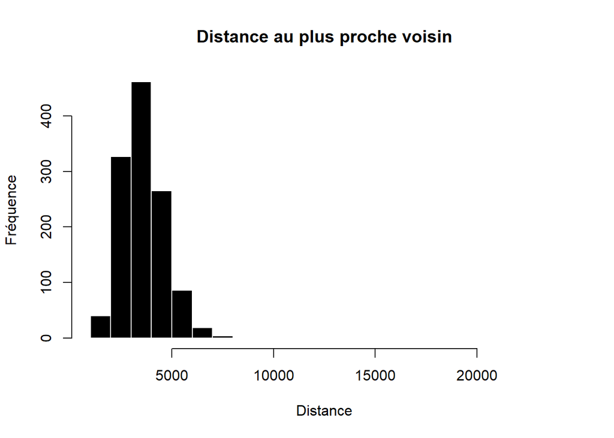

```r
hist(unlist(distPPV), breaks = 20,
     main = "Distance au plus proche voisin",
     col = "black", border = "white", xlab = "Distance", ylab = "Fréquence")
```

```r
# pour convertir les communes en objet nb (indispensable pour le calcul de l'indice de Moran)
nbCom <- poly2nb(pl = Communes,
                 snap = 50,
                 queen = TRUE)

# pour identifier les communes sans voisins topologiques (regions with no links), c'est-à-dire les îles
summary(nbCom)
```

```
## Neighbour list object:
## Number of regions: 1206
## Number of nonzero links: 6588
## Percentage nonzero weights: 0.4529591
## Average number of links: 5.462687
## 8 regions with no links:
## 14, 427, 488, 1020, 1036, 1037, 1038, 1039
## 10 disjoint connected subgraphs
## Link number distribution:
##
##   0   1   2   3   4   5   6   7   8   9  10  11  12  14  18
##   8  19  51 107 197 246 241 164  94  42  21  10   2   3   1
## 19 least connected regions:
## 176 185 322 340 369 428 438 441 459 468 469 520 560 563 961 1014 1056 1102 1132 with 1 link
## 1 most connected region:
## 82 with 18 links
```

```r
# création d'une liste des communes sans voisins qui correspondent aux îles (à partir de l'indice des lignes)
Iles <- which(card(nbCom) == 0)

# suppression des îles sans quoi le calcul de l'indice de Moran n'est pas possible
CommunesBZHDVF <- Communes[-Iles, ]

# pour reconvertir les communes (sans les îles) en objet nb
nbCom <- poly2nb(pl = CommunesBZHDVF,
                 snap = 50,
                 queen = TRUE)

#calcul du test de Moran
print(moran.test(CommunesBZHDVF$Prixm2Moyen,
                 listw = nb2listw(nbCom)))
```

```
##
##  Moran I test under randomisation
##
## data:  CommunesBZHDVF$Prixm2Moyen
## weights: nb2listw(nbCom)
##
## Moran I statistic standard deviate = 44.098, p-value <
## 0.00000000000000022
## alternative hypothesis: greater
## sample estimates:
## Moran I statistic       Expectation          Variance
##      0.8043797446     -0.0008354219      0.0003334097
```

#### 1.6.1.2 Carte lissée des prix de l’immobilier au m² calculés à partir des valeurs agrégées par commune sur l’ensemble de la Bretagne

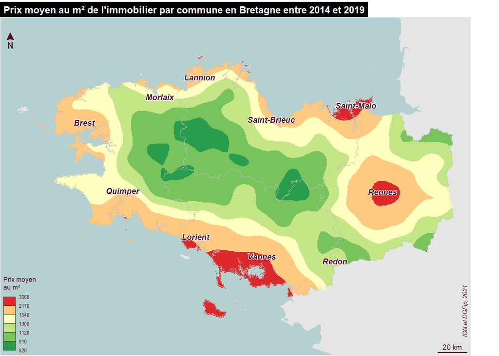

```r
# pour convertir les objets sf en objets terra
Emprise <- vect(CommunesBZHDVF)
Centroids <- vect(CommunesBZHDVFCentroids)

# pour créer le raster qui servira de support aux calculs
r0 <- rast(Emprise, resolution = 500)

# pour "rasteriser" les prix au m² des pseudo-centroïdes
valeurs <- rasterize(Centroids, r0, field = "Prixm2Moyen", fun = "first")
presence <- ifel(is.na(valeurs), 0, 1)   # 1 là où il y a un point, 0 ailleurs. ifel est la fonction terra équivalente à ifelse et est adaptée aux objets rasters
valeurs  <- ifel(is.na(valeurs), 0, valeurs)
# Ici, seuls les pixels contenant les centroïdes des communes ont un prix moyen au m², tous les autres reçoivent la valeur 0.

# calcul de la matrice des poids des pixels qui va décroissant avec la distance et la fonction de lissage (fonction terra)
matrice_poids <- focalMat(r0, d = 5000, type = "Gauss")

# pour calculer le numérateur et le dénominateur du lissage
num <- focal(valeurs,
             w = matrice_poids,
             fun = "sum",
             fillvalue = 0)

den <- focal(presence,
             w = matrice_poids,
             fun = "sum",
             fillvalue = 0)

# pour obtenir la surface lissée et la restreindre au contour de la Bretagne
cartelissee.raster <- mask(num / den, Emprise)
names(cartelissee.raster) <- "Prixm2Lisse"

# Paramétrage des marges de la fenêtre pour maximiser l'emprise de la carte
op <- par(mar = c(0, 0, 1.2, 2))

# pour afficher la surface lissée et habiller la carte
# Calcul des seuils
bks <- unique(mf_get_breaks(values(cartelissee.raster), breaks = "q6"))

# Création d'une palette de couleurs (double gradation harmonique)
cols <- c("#2a9c4e", "#77c35c", "#c4e687", "#ffffc0", "#fec981", "#dc292c")

# Affichage de tous les départements en arrière-plan, en centrant la carte sur la région Bretagne
plot(st_geometry(departements), col = "grey90", border = NA, bg = "#B5D0D0", xlim = c(st_bbox(Communes)[1], st_bbox(Communes)[3]), ylim = c(st_bbox(Communes)[2], st_bbox(Communes)[4]))

# Affichage de la surface lissée
plot(cartelissee.raster, breaks = bks, col = cols, add = T, legend = F)
plot(st_geometry(depBZH), border = "grey", lwd = 0.05, lty = 3, add = T)

# Ajouter les étiquettes des communes sélectionnées plus haut
mf_label(Selection_Communes, var = "NOM_COM", halo = TRUE, bg = "white", r = 0.05, cex = 0.7, pos = 3, font = 4, offset = 0)

mf_legend(type = "choro",
          pos = "bottomleft",
          title = "Prix moyen \nau m²",
          val = bks,
          no_data = FALSE,
          val_rnd = -1,
          pal = cols,
          size = 0.7)

# Habillage de la carte
mf_title("Prix moyen au m² de l'immobilier par commune en Bretagne entre 2014 et 2019", cex = 0.8, tab = TRUE, fg = "white", bg = "black", line = 1, pos = "left")

mf_arrow(adj = c(1,-3))
mf_scale()

mf_credits(txt = "          IGN et DGFip, 2021", cex = 0.5, pos = 'rightbottom')
```

```r
par(op) # pour réinitialiser les paramètres de la fenêtre graphique
```

### 1.6.2 Lissage spatial des prix de l’immobilier au m² calculés directement à partir des mutations immobilières

#### 1.6.2.1 Calcul des distances au plus proche voisin et de l’auto-corrélation spatiale des prix au m²

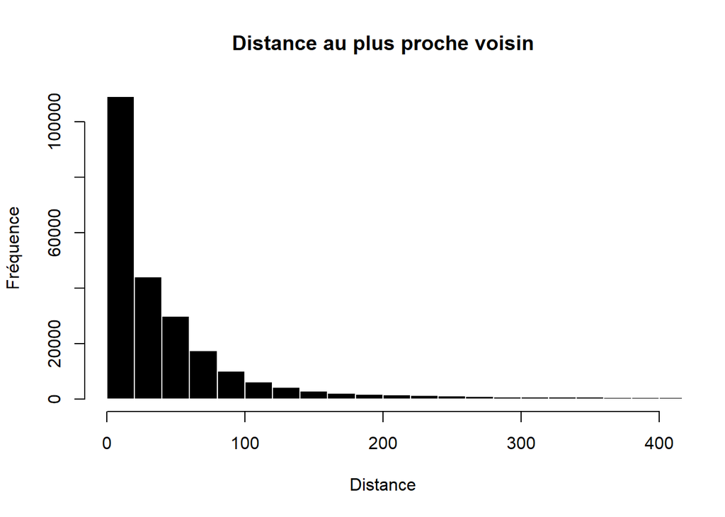

```r
# Convertir l'objet sf en un objet spatstat de type ppp (utile pour calculer les distances au plus proche voisin et l'indice du plus proche voisin)
# Extraire les coordonnées des points
coords <- st_coordinates(DVFgeo)

# Définir l'emprise où se trouvent les points (fonction spatstat)
emprise <- as.owin(st_bbox(DVFgeo))

# Créer un objet ppp (format spatstat)
points_ppp <- ppp(coords[,1], coords[,2], window = emprise)

# Calculer la distance au plus proche voisin (PPV) pour chaque point (fonction spatstat)
distances_au_PPV <- round(nndist(points_ppp))

# Histogramme des distances au plus proche voisin
hist(distances_au_PPV, nclass = 500,
     main = "Distance au plus proche voisin",
     col = "black", border = "white", xlab = "Distance", ylab = "Fréquence", xlim = c(0,400))
```

```r
# Récupérer l'identifiant du plus proche voisin (PPV) de chaque point
id_PPV <- nnwhich(points_ppp)
df_PPV <- as.data.frame(id_PPV)
df_PPV$id <- as.integer(rownames(df_PPV))
df_PPV <- df_PPV[ , c("id", "id_PPV")] # pour réagencer les colonnes
View(df_PPV)

# Créer une liste dans laquelle chaque élément contient l'indice du PPV (format requis pour le calcul de l'indice de Moran avec le package spdep)
PPV <- split(df_PPV$id_PPV, df_PPV$id)

# Attribuer la classe "nb" à l'objet précédent (classe requise pour le calcul de l'indice de Moran avec le package spdep)
class(PPV) <- "nb"

# calcul du test de Moran (fonction spdep)
print(moran.test(DVFgeo$prixm2,
                 listw = nb2listw(PPV)))
```

```
##
##  Moran I test under randomisation
##
## data:  DVFgeo$prixm2
## weights: nb2listw(PPV)
##
## Moran I statistic standard deviate = 251.14, p-value <
## 0.00000000000000022
## alternative hypothesis: greater
## sample estimates:
## Moran I statistic       Expectation          Variance
##    0.624353965398   -0.000004038038    0.000006180594
```

#### 1.6.2.2 Carte lissée des prix de l’immobilier au m² calculés directement à partir des mutations immobilières sur l’ensemble de la Bretagne

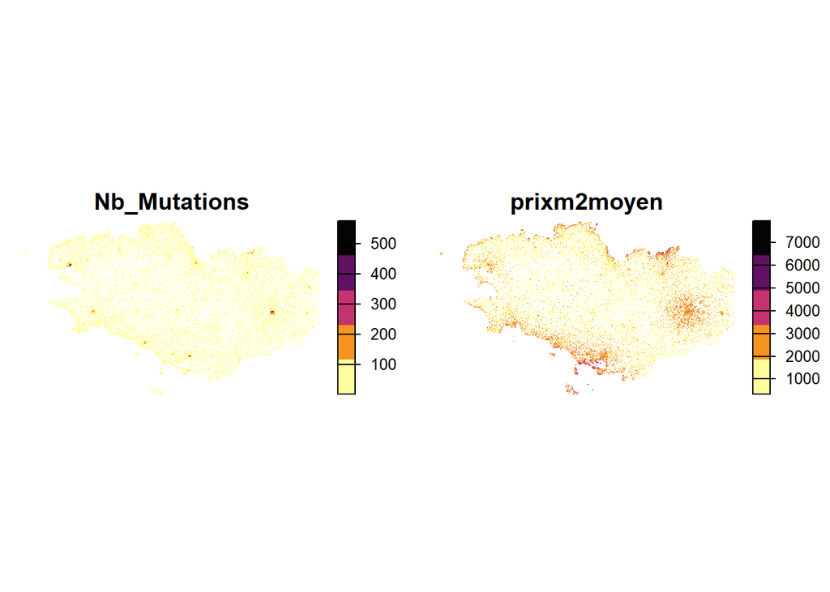

```r
# pour convertir les objets sf en objets terra (SpatVector)
pts <- vect(DVFgeo)

# pour créer le raster (SpatRaster) qui servira de support aux calculs
r0  <- rast(pts, resolution = 500)

# pour "rasteriser" les prix au m² des mutations
nb  <- rasterize(pts, r0, fun = "count")  # nombre de mutations dans un même pixel
moy <- round(rasterize(pts, r0, field = "prixm2", fun = "mean")) # moyenne (si plusieurs points dans un même pixel)
names(nb) <- "Nb_Mutations"
names(moy) <- "prixm2moyen"

# affichage des deux variables
plot(c(nb, moy),
     col  = hcl.colors(5, "Inferno", rev = TRUE),
     axes = FALSE,
     mar  = c(1, 1, 2, 4))
```

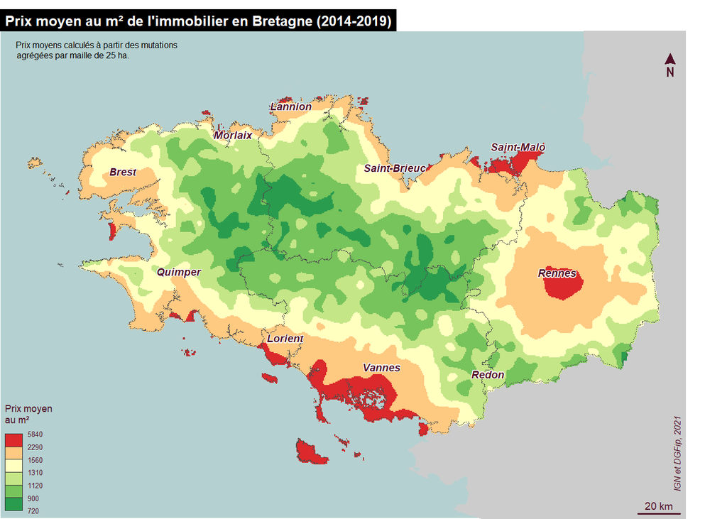

```r
# calcul de la matrice des poids des pixels qui va décroissant avec la distance et la fonction de lissage (fonction terra)
matrice_poids2 <- focalMat(r0, d = 2000, type = "Gauss")

# définition des valeurs prises par les pixels (remplacement des NA par des 0)
presence <- ifel(is.na(moy), 0, 1)
valeurs  <- ifel(is.na(moy), 0, moy)

# calcul du numérateur et du dénominateur
num <- focal(valeurs,
             w = matrice_poids2,
             fun = "sum",
             fillvalue = 0)

den <- focal(presence,
             w = matrice_poids2,
             fun = "sum",
             fillvalue = 0)

# calcul du lissage spatial
grille_lissee_prix_m2 <- num / den

# découpage du raster pour ne garder que la partie située sur l'emprise de la Bretagne
grille_lissee_prix_m2 <- mask(grille_lissee_prix_m2, vect(depBZH))

# pour afficher la surface lissée et définir l'habillage de la carte
# Calcul des seuils
bks <- unique(mf_get_breaks(values(grille_lissee_prix_m2), breaks = "q6"))

# Création d'une palette de couleurs (double gradation harmonique)
cols <- c("#2a9c4e", "#77c35c", "#c4e687", "#ffffc0", "#fec981", "#dc292c")

# sélection des communes dont le nom sera affiché sur la carte
liste_noms <- c("Rennes", "Redon", "Vannes", "Lorient", "Quimper", "Brest", "Morlaix", "Lannion", "Saint-Brieuc", "Saint-Malo")
Selection_Communes <- Communes[which(Communes$NOM_COM %in% liste_noms), ]

#paramétrage de la fenêtre graphique
op <- par(mar = c(0,0,1.5,2))

# Affichage des départements de la Bretagne et des départements limitrophes en arrière-plan, en centrant la carte sur la région Bretagne
plot(st_geometry(departements), col = "grey80", border = NA, bg = "#B5D0D0", xlim = c(st_bbox(depBZH)[1], st_bbox(depBZH)[3]), ylim = c(st_bbox(depBZH)[2], st_bbox(depBZH)[4]))

# Affichage de la surface lissée
plot(grille_lissee_prix_m2, breaks = bks, col = cols, legend = FALSE, axes = FALSE, add = TRUE)
plot(st_geometry(depBZH), border = "grey30", lwd = 0.2, lty = 3, add = T)

# Ajouter les étiquettes des communes sélectionnées plus haut
mf_label(Selection_Communes, var = "NOM_COM", halo = TRUE, bg = "white", r = 0.05, cex = 0.6, pos = 3, font = 4, offset = 0.5)

# Habillage de la carte
mf_title("Prix moyen au m² de l'immobilier en Bretagne (2014-2019)", cex = 0.8, tab = TRUE, fg = "white", bg = "black", line = 1, pos = "left")

mf_scale()

mf_arrow(pos = "topright", adj = c(-1,-3))

mf_legend(type = "choro",
          pos = "bottomleft",
          title = "Prix moyen \nau m²",
          val = bks,
          no_data = FALSE,
          val_rnd = -1,
          pal = cols,
          size = 0.7)

mf_credits(txt = "          IGN et DGFip, 2021", cex = 0.5, pos = 'rightbottom')

# Ajout d'une indication sur la méthode de calcul en marge de la carte
mtext("Prix moyens calculés à partir des mutations\nagrégées par maille de 25 ha.", side = 3, line = -1.5, adj = 0.03, cex = 0.5)
```

```r
par(op) # pour réinitialiser les paramètres graphiques
```

#### 1.6.2.3 Carte lissée des prix de l’immobilier au m² avec isolignes sur l’ensemble de la Bretagne (variante)

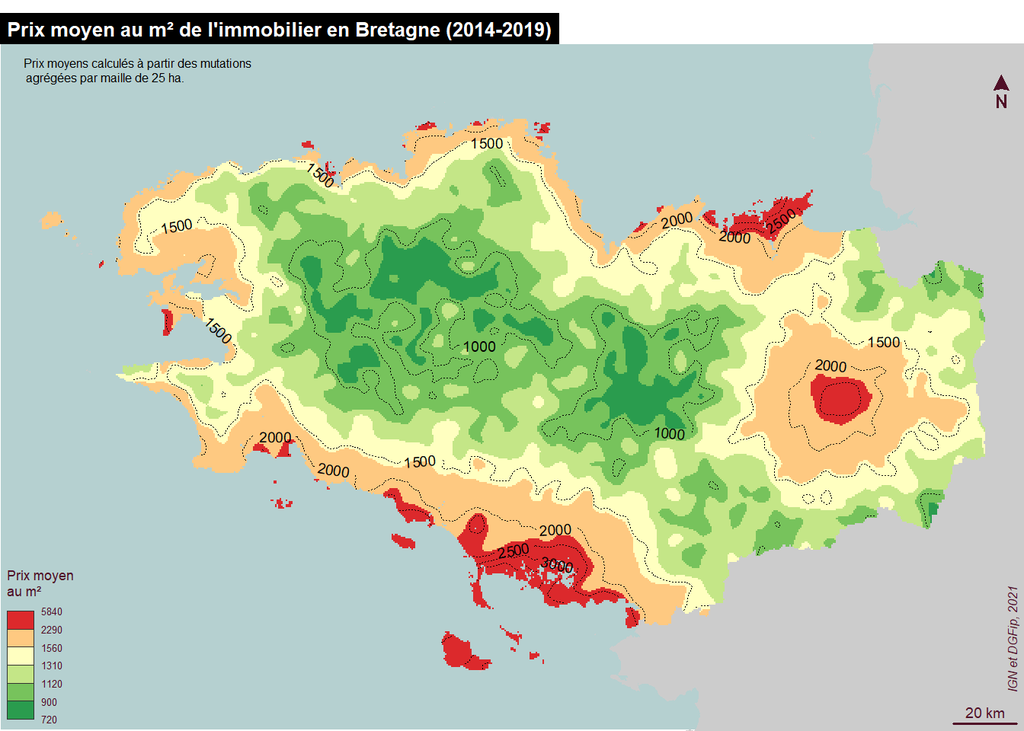

```r
# Pour rajouter des contours avec les valeurs sur les isolignes

#paramétrage de la fenêtre graphique
op <- par(mar = c(0,0,1.5,0))

# Affichage des départements de la Bretagne et des départements limitrophes en arrière-plan, en centrant la carte sur la région Bretagne
plot(st_geometry(departements), col = "grey80", border = NA, bg = "#B5D0D0", xlim = c(st_bbox(depBZH)[1], st_bbox(depBZH)[3]), ylim = c(st_bbox(depBZH)[2], st_bbox(depBZH)[4]))

# Affichage de la surface lissée
plot(grille_lissee_prix_m2, breaks = bks, col = cols, legend = FALSE, axes = FALSE, add = TRUE)

# Affichage des isolignes avec leur valeur
contour(grille_lissee_prix_m2, lwd = 0.5, lty = 3, add = TRUE)

# Habillage de la carte
mf_title("Prix moyen au m² de l'immobilier en Bretagne (2014-2019)", cex = 0.8, tab = TRUE, fg = "white", bg = "black", line = 1, pos = "left")

mf_scale()

mf_arrow(pos = "topright", adj = c(-1,-3))

mf_legend(type = "choro",
          pos = "bottomleft",
          title = "Prix moyen \nau m²",
          val = bks,
          no_data = FALSE,
          val_rnd = -1,
          pal = cols,
          size = 0.7)

mf_credits(txt = "          IGN et DGFip, 2021", cex = 0.5, pos = 'rightbottom')

# Ajout d'une indication sur la méthode de calcul en marge de la carte
mtext("Prix moyens calculés à partir des mutations\nagrégées par maille de 25 ha.", side = 3, line = -1.5, adj = 0.03, cex = 0.5)
```

```r
par(op) # pour réinitialiser les paramètres graphiques
```

### 1.6.3 Carte du volume des mutations sous forme de contour de relief (méthode de Tanaka)

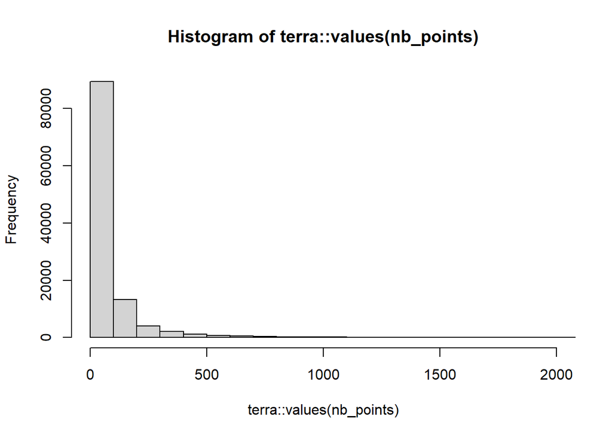

```r
# noyau circulaire (rayon 2000 m) : matrice de 0/1, sans pondération
matrice_poids3 <- focalMat(r0, d = 2000, type = "circle")
matrice_poids3[matrice_poids3 > 0] <- 1

# nombre de mutations par pixel (NA remplacés par 0)
nb <- subst(rasterize(pts, r0, fun = "count"), NA, 0)

# nombre de mutations dans la fenêtre circulaire de 2000 m autour de chaque pixel
nb_points <- focal(nb, w = matrice_poids3, fun = "sum", fillvalue = 0)

# découpage du raster correspondant au nombre de mutations, sur l'emprise de la Bretagne
nb_points <- mask(nb_points, depBZH)

# Histogramme et définition des seuils pour la discrétisation
hist(terra::values(nb_points), nclass = 100, xlim = c(0,2000))
```

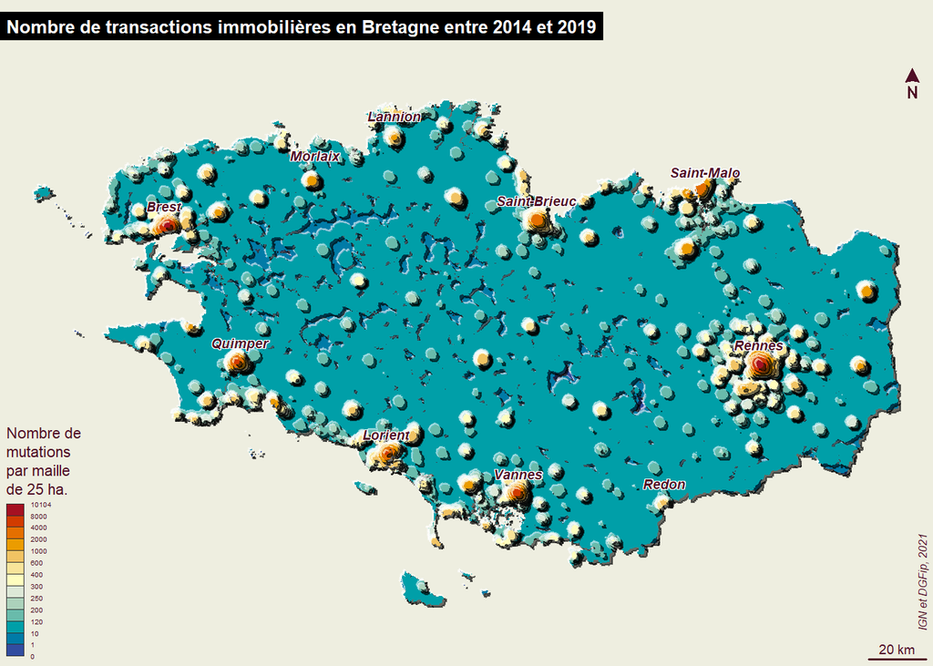

```r
bks <- c(0,1,10,120,200,250,300,400,600,1000,2000,4000,8000,max(values(nb_points), na.rm = TRUE))

#paramétrage de la fenêtre graphique
op <- par(mar = c(0,0,1.5,0), bg = "ivory2")

# définition d'une palette de couleurs
palette <- hcl.colors(n = length(bks)-1, palette = "RdYlBu", rev = TRUE)

#Affichage de la carte en contour de relief (/!\ UN PEU LONG)
tanaka(x = nb_points,
       breaks = bks,
       col = palette,
       shift = 500,
       mask = depBZH,
       legend.pos = NA)

# Ajouter les étiquettes des communes sélectionnées plus haut
mf_label(Selection_Communes, var = "NOM_COM", halo = TRUE, bg = "white", r = 0.05, cex = 0.6, pos = 3, font = 4, offset = 0.5)

# Habillage de la carte
mf_title("Nombre de transactions immobilières en Bretagne entre 2014 et 2019", cex = 0.8, tab = TRUE, fg = "white", bg = "black", line = 1, pos = "left")

mf_scale()

mf_arrow(pos = "topright", adj = c(-1,-3))

mf_credits(txt = "          IGN et DGFip, 2021", cex = 0.5, pos = 'rightbottom')

mf_legend(
  type = "choro",
  val = bks,
  pal = palette,
  title = "Nombre de\nmutations\npar maille\nde 25 ha.",
  pos = "bottomleft",
  size = 0.5,
  title_cex = 0.7
)
```

```r
par(op) # pour réinitialiser les paramètres graphiques
```

### 1.6.4 Carte du volume des mutations sous forme de stalagmites

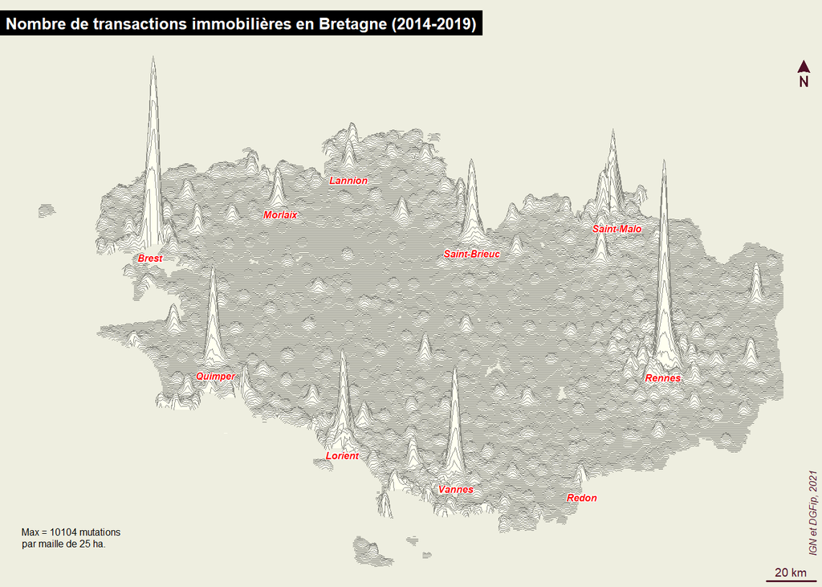

```r
#paramétrage de la fenêtre graphique
op <- par(mar = c(0,0,1.5,0), bg = "ivory2")

#Affchage de la carte en stalagmites
linemap(nb_points,
        k = 8,
        col = "ivory1",
        border = "ivory4",
        lwd = 0.1)

# Ajouter les étiquettes des communes sélectionnées plus haut
mf_label(Selection_Communes, var = "NOM_COM", halo = TRUE, col = "red", bg = "white", r = 0.05, cex = 0.5, pos = 3, font = 4, offset = -1)

# Habillage de la carte
mf_title("Nombre de transactions immobilières en Bretagne (2014-2019)", cex = 0.8, tab = TRUE, fg = "white", bg = "black", line = 1, pos = "left")

mf_scale()

mf_arrow(pos = "topright", adj = c(-1,-3))

mf_credits(txt = "          IGN et DGFip, 2021", cex = 0.5, pos = 'rightbottom')

# Ajout du max comme indication en marge de la carte
mtext(paste0("Max = ", round(max(values(nb_points), na.rm = TRUE)), " mutations\npar maille de 25 ha."), side = 1, line = -2.5, adj = 0.03, cex = 0.5)
```

```r
par(op) # pour réinitialiser les paramètres graphiques
```

## 1.7 Cartogramme et lissage spatial

### 1.7.1 Création d’un objet correspondant aux EPCI bretons et agrégation des valeurs de l’immobilier

```r
# pour créer une couche des EPCI à partir des communes
EPCI.BZH <- Communes %>% group_by(CODE_EPCI) %>% summarize()

# pour récupérer l'id des EPCI sur chaque mutation
DVFgeo.enrichi <- st_join(DVFgeo, EPCI.BZH["CODE_EPCI"]) |> st_drop_geometry()

# pour calculer le nombre de mutations et leur prix moyen par EPCI (package data.table)
setDT(DVFgeo.enrichi)  # Convertir le dataframe en data.table
EPCI.enrichi <- DVFgeo.enrichi[, .(NbMutations = .N,
                                   prixm2moyen = round(mean(prixm2))),
                               by = CODE_EPCI]

# jointure attributaire pour récupérer les résultats dans l'objet sf EPCI
EPCI.BZH <- merge(EPCI.BZH, EPCI.enrichi, by = "CODE_EPCI", all = TRUE)
rm(DVFgeo.enrichi, EPCI.enrichi)
```

### 1.7.2 Création d’un cartogramme avec le nombre de mutations par EPCI

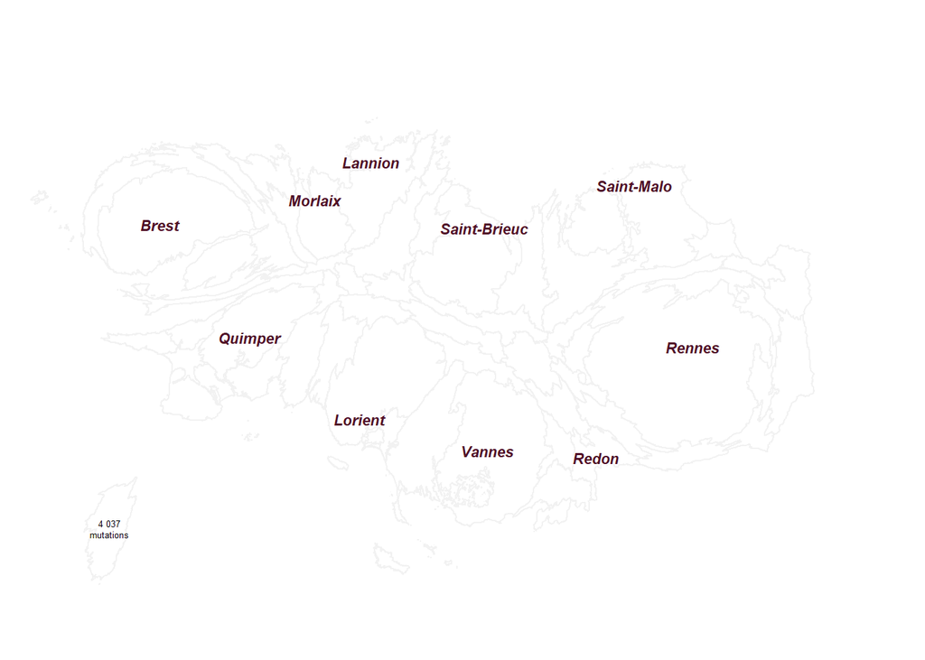

```r
# pour créer un cartogramme suivant le nombre de mutations par EPCI
EPCI.BZH.cartogram <- cartogramR(EPCI.BZH, count = "NbMutations")

# Pour déplacer les noms des étiquettes (nom des quelques communes choisies) en fonction de la déformation utilisée pour construire le cartogramme
Selection_Communes.deplacees <- warp_features(Selection_Communes, EPCI.BZH.cartogram)

# Paramétrage des marges de la fenêtre pour maximiser l'emprise de la carte
op <- par(mar = c(0, 0, 1.2, 3))

# pour afficher le cartogramme
plot(EPCI.BZH.cartogram, border = "grey95")

# Ajouter les étiquettes des communes sélectionnées plus haut
mf_label(Selection_Communes.deplacees, var = "NOM_COM", halo = TRUE, bg = "white", r = 0.05, cex = 0.7, pos = 3, font = 4, offset = 0)

# ajout de la légende de déformation
# la fonction n'est pas encore intégrée au package. Elle est disponible dans le fichier 'add_legend.R' qui se trouve dans le répertoire de travail
source("add_legend.R") # pour indiquer où se trouve la fonction 'add_legend.R'

add_legend(EPCI.BZH.cartogram,
           var = "NbMutations",
           label.unit = "mutations",
           x.offset = 0.1,
           y.offset = 0.1,
           position = "bottomleft",
           col = "white",
           border = "grey95")
```

```r
par(op) # pour réinitialiser les paramètres de la fenêtre graphique
```

### 1.7.3 Cartogramme montrant le nombre de mutations et les prix au m² de l’immobilier lissés

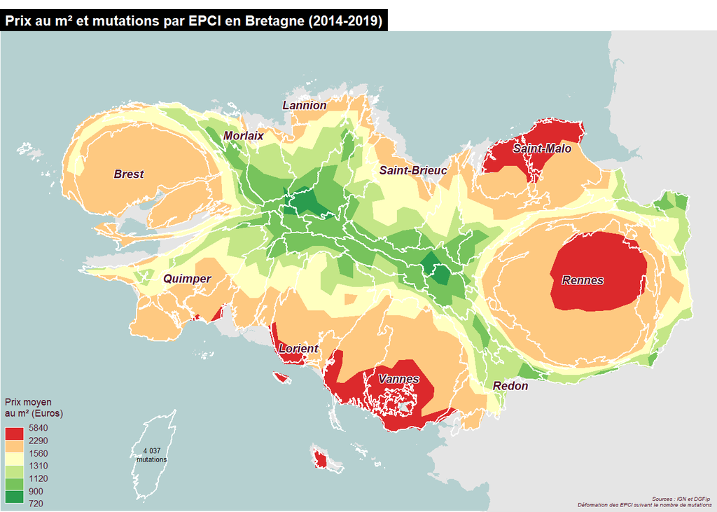

```r
# Calcul des seuils
bks <- unique(mf_get_breaks(values(grille_lissee_prix_m2), breaks = "q6"))

# classification de la surface lissée préalablement calculée
cartelissee.reclass <- classify(grille_lissee_prix_m2, bks, include.lowest = TRUE, brackets = TRUE)

# vectorisation de la surface reclassée
cartelissee.vecteur <- st_as_sf(as.polygons(cartelissee.reclass))

# Pour déformer la surface lissée suivant les mêmes paramètres que ceux ayant servi à construire le cartogramme
cartelissee.vecteur.drapee <- warp_features(cartelissee.vecteur, EPCI.BZH.cartogram)

# pour généraliser les contours de cartelissee.vecteur.drapee (on garde 5% des sommets initiaux)
cartelissee.vecteur.drapee <- ms_simplify(cartelissee.vecteur.drapee, keep = 0.05, keep_shapes = TRUE)

# conversion de l'objet cartogram EPCI en objet sf
EPCI.BZH.cartogram.sf <- EPCI.BZH.cartogram$cartogram

# Paramétrage des marges de la fenêtre pour maximiser l'emprise de la carte
op <- par(mar = c(0, 0, 1.5, 0))

# Affichage de tous les départements en arrière-plan, en centrant la carte sur la région Bretagne
plot(st_geometry(departements), col = "grey90", border = NA, bg = "#B5D0D0", xlim = c(st_bbox(Communes)[1], st_bbox(Communes)[3]), ylim = c(st_bbox(Communes)[2], st_bbox(Communes)[4]))

plot(cartelissee.vecteur.drapee, breaks = bks, border = NA, col = cols, add = TRUE)

mf_legend(
  type = 'choro',
  pos = "bottomleft",
  val = bks,
  pal = cols,
  title = "Prix moyen \nau m² (Euros)",
  val_cex = 0.5,
  size = 0.7,
  no_data = FALSE,
  box_border = "white",
  val_rnd = -1,
)

# Habillage de la carte
mf_title("Prix au m² et mutations par EPCI en Bretagne (2014-2019)", cex = 0.8, tab = TRUE, fg = "white", bg = "black", line = 1, pos = "left")

mf_credits(txt = "Sources : IGN et DGFip \nDéformation des EPCI suivant le nombre de mutations", cex = 0.3, pos = 'bottomright')

plot(st_geometry(EPCI.BZH.cartogram.sf), border = "white", lwd = 1, add = TRUE)

# Ajouter les étiquettes des communes sélectionnées plus haut
mf_label(Selection_Communes, var = "NOM_COM", halo = TRUE, bg = "white", r = 0.05, cex = 0.7, pos = 3, font = 4, offset = 0)

#affichage de la légende du cartogramme
add_legend(EPCI.BZH.cartogram,
           var = "NbMutations",
           label.unit = "mutations",
           x.offset = 0.2,
           y.offset = 0.05,
           position = "bottomleft",
           col = NA,
           border = "white")
```

```r
par(op) # pour réinitialiser les paramètres graphiques
```

## 1.8 Elaboration d’une typologie à partir d’indicateurs immobiliers et cartographie des sous-marchés associés

### 1.8.1 Création d’un tableau avec les variables à soumettre à la CAH pour chacune des communes

```r
CommunesDVFClassif1 <- as.data.frame(Communes) %>%
  select(INSEE_COM,
         NbMutations,
         PrixMoyen,
         Prixm2Moyen)
CommunesDVFClassif1 <- CommunesDVFClassif1 %>% na.omit()
CommunesDVFClassif <- CommunesDVFClassif1 %>% select(NbMutations, PrixMoyen, Prixm2Moyen)
```

### 1.8.2 Centrage et réduction des variables

```r
CommunesDVFClassifscale <- scale(CommunesDVFClassif)
```

### 1.8.3 Classification

```r
CAHCommunes <- agnes(CommunesDVFClassifscale,
                     metric = "euclidean",
                     method = "ward")
```

### 1.8.4 Graphiques des gains d’inertie inter-classe

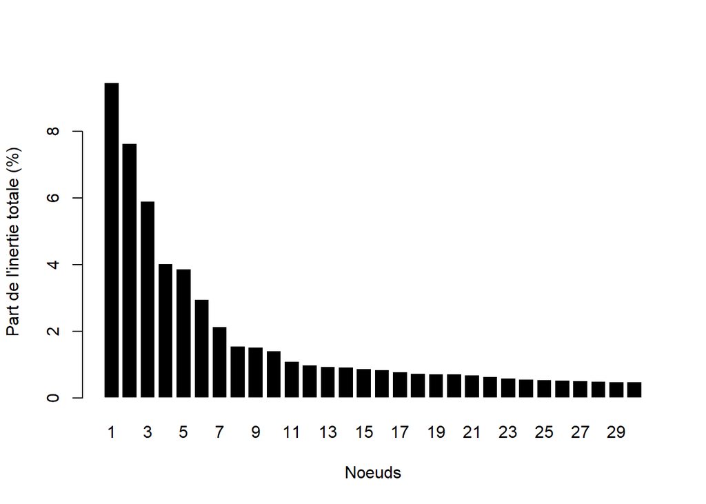

```r
sortedHeight <- sort(CAHCommunes$height, decreasing = TRUE)
relHeight <- sortedHeight / sum(sortedHeight) * 100
barplot(relHeight[1:30], names.arg = seq(1, 30, 1), col = "black", border = "white", xlab = "Noeuds", ylab = "Part de l'inertie totale (%)")
```

### 1.8.5 Arbre hiérarchique

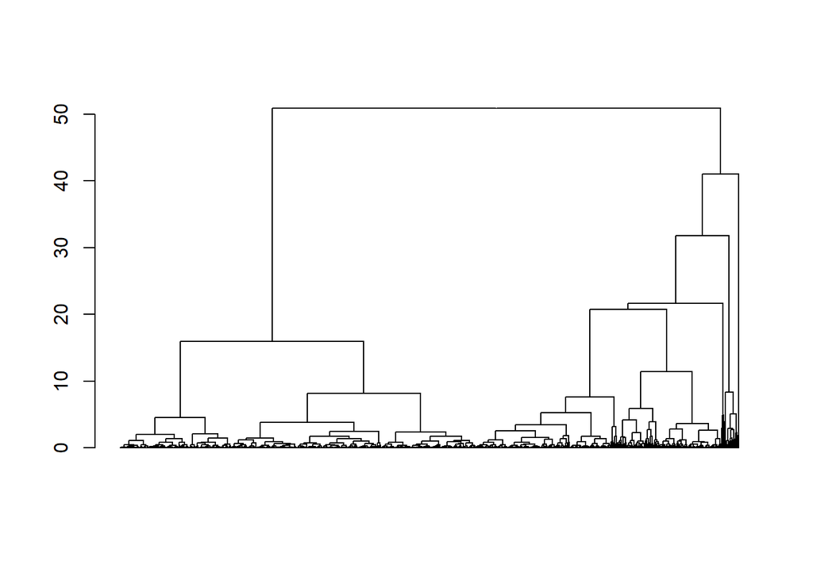

```r
dendroCSP <- as.dendrogram(CAHCommunes)
plot(dendroCSP, leaflab = "none")
```

### 1.8.6 Partition (en n classes)

```r
clusCSP <- cutree(CAHCommunes, k = 7)
CommunesCluster <- as.data.frame(CommunesDVFClassif1)
CommunesCluster$CLUSIMMO <- factor(clusCSP,
                                   levels = 1:7,
                                   labels = paste("Classe", 1:7))
```

### 1.8.7 Création d’un tableau caractérisant les groupes

```r
RecapCAHRegion <- CommunesCluster %>%
  group_by(CLUSIMMO) %>%
  summarise(
  Nbcommunes = n(),
  NbMutationsmoyen = round(mean(NbMutations)),
  Prixmoyen = round(mean(PrixMoyen)),
  Prixm2moyen = round(mean(Prixm2Moyen)))
print(RecapCAHRegion)
```

```
## # A tibble: 7 × 5
##   CLUSIMMO Nbcommunes NbMutationsmoyen Prixmoyen Prixm2moyen
##   <fct>         <int>            <dbl>     <dbl>       <dbl>
## 1 Classe 1        218               73     82662         936
## 2 Classe 2        277              203    151883        1557
## 3 Classe 3        474               90    117895        1221
## 4 Classe 4         28              428    307194        3464
## 5 Classe 5        202              309    197073        2055
## 6 Classe 6          5             5417    151431        2020
## 7 Classe 7          2            15796    140873        2087
```

### 1.8.8 Graphique des écarts à la moyenne

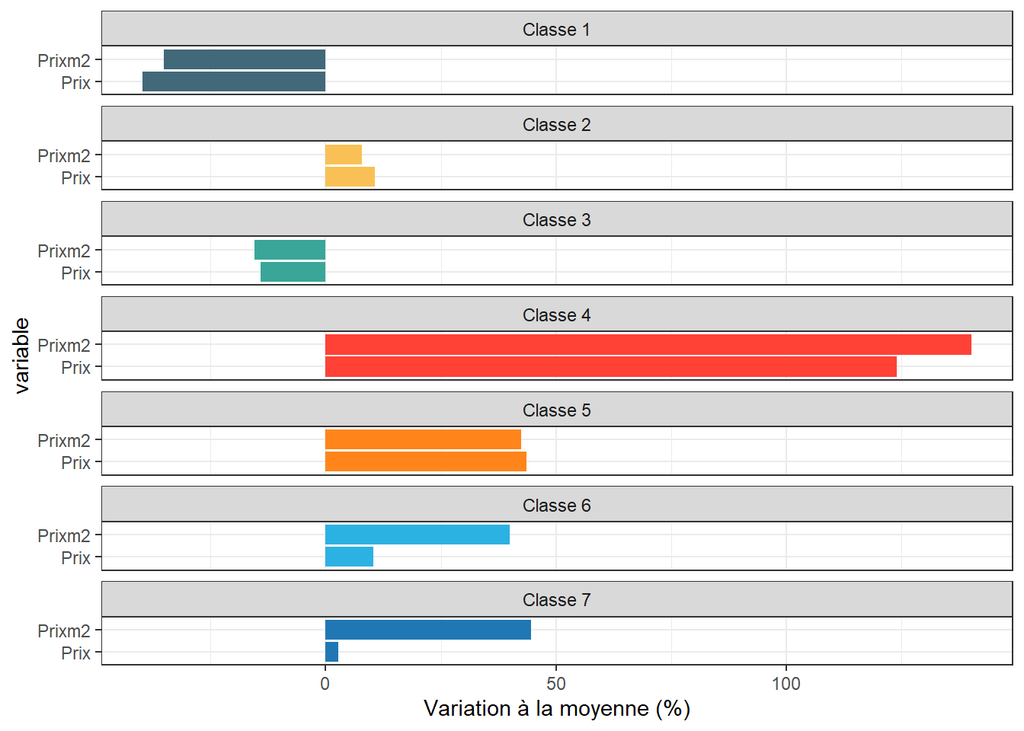

```r
SyntheseCAHRegion <- RecapCAHRegion %>%
  ungroup() %>%
  mutate(
    NbmutationBZH = mean(CommunesDVFClassif$NbMutations, na.rm = TRUE),
    PrixBZH       = mean(CommunesDVFClassif$PrixMoyen, na.rm = TRUE),
    Prixm2BZH     = mean(CommunesDVFClassif$Prixm2Moyen, na.rm = TRUE),
    NbMutations   = (NbMutationsmoyen - NbmutationBZH) / NbmutationBZH * 100,
    Prix          = (Prixmoyen - PrixBZH) / PrixBZH * 100,
    Prixm2        = (Prixm2moyen - Prixm2BZH) / Prixm2BZH * 100
  ) %>%
  dplyr::select(CLUSIMMO, Prix, Prixm2)

SyntheseLong <- tidyr::pivot_longer(SyntheseCAHRegion,
                                    cols = c(Prix, Prixm2),
                                    names_to = "variable",
                                    values_to = "value")

ggplot(SyntheseLong, aes(x = variable, y = value, fill = factor(CLUSIMMO))) +
    geom_col() +
    coord_flip() +
    scale_fill_manual(values = c("#416979","#f9c155","#39a699","#FF4136","#FF851B","#2cb1e3","#1f78b4")) +
    ylab("Variation à la moyenne (%)") +
    theme_bw() +
    theme(legend.position = "none") +
    facet_wrap(~ CLUSIMMO, ncol = 1)
```

### 1.8.9 Représentation cartographique des classes issues de la CAH

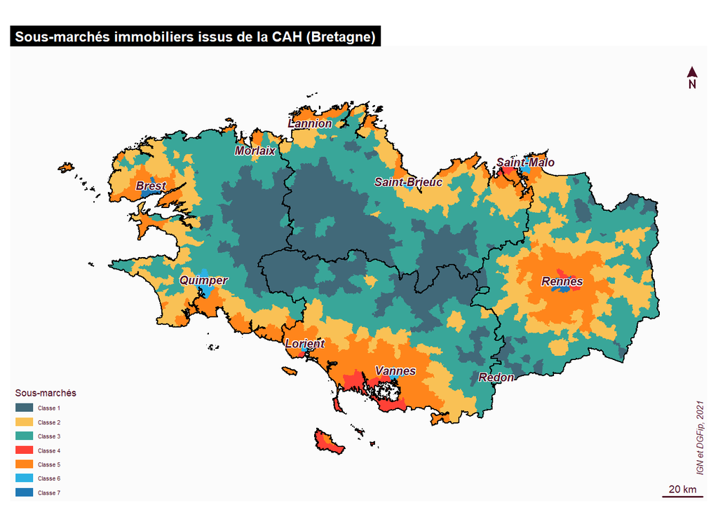

```r
CommunesDVFCAH <- merge(Communes, CommunesCluster, by = "INSEE_COM")

# Paramétrage des marges de la fenêtre pour maximiser l'emprise de la carte
op <- par(mar = c(0, 0, 0.9, 0))

cols <- c("#416979","#f9c155","#39a699","#FF4136","#FF851B","#2cb1e3", "#1f78b4")

mf_map(
  type = 'typo',
  x = CommunesDVFCAH,
  var = "CLUSIMMO",
  pal = cols,
  border = NA,
  leg_pos = NA
  )

mf_legend(
  type = 'typo',
  pos = "bottomleft",
  val = unique(CommunesDVFCAH$CLUSIMMO),
  pal = cols,
  title = "Sous-marchés",
  val_cex = 0.35,
  size = 0.7,
  box_cex = c(1, 0.75),
  box_border = "white"
)

# Ajout des départements de la région
plot(st_geometry(depBZH), lwd = 1, col = NA, border = "#000000", add = TRUE)

# Habillage de la carte
mf_title("Sous-marchés immobiliers issus de la CAH (Bretagne)", cex = 0.8, tab = TRUE, fg = "white", bg = "black", line = 1, pos = "left")

mf_scale()

mf_arrow(pos = "topright", adj = c(-1,-3))

mf_credits(txt = "          IGN et DGFip, 2021", cex = 0.5, pos = 'rightbottom')

# Ajouter les étiquettes des communes sélectionnées plus haut
mf_label(Selection_Communes, var = "NOM_COM", halo = TRUE, bg = "white", r = 0.05, cex = 0.7, pos = 3, font = 4, offset = 0)
```

```r
par(op) # pour réinitialiser les paramètres de la fenêtre graphique
```

### 1.8.10 Export des communes contenant la typologie issue de la CAH au format geopackage

```r
st_write(CommunesDVFCAH, "Resultats/CommunesBZHDVF.gpkg", append = FALSE) # pour une utilisation dans un SIG par exemple
```

```
## Deleting layer `CommunesBZHDVF' using driver `GPKG'
## Writing layer `CommunesBZHDVF' to data source
##   `Resultats/CommunesBZHDVF.gpkg' using driver `GPKG'
## Writing 1206 features with 23 fields and geometry type Multi Polygon.
```